# Final HW4

AnnaClaire Marley

6/5/2019

**1. Write down a plausible functional form for the marginal cost of abatement for sector A. Use regression analysis to estimate the parameters of that function. Repeating this for sectors B, C, and D will give you a model of the marginal cost of abatement function for each sector. How well do your models fit the data for each sector? You may need to experiment with different functional forms. Produce a plot of the estimated marginal abatement cost functions in all four sectors (this plot should go in your memo).**

Regression fit *Sector A:*

Price = -8.64 + 0.58*(Abatement)

Data looked relatively linear and a linear model described 0.904 of the variance of the data.

*Sector B:*

Price = 9.32 + 0.2*(Abatement)

Data looked relatively linear and a linear model described 0.5355 of the variance of the data therefore the model did not fit the data as well as sector A.

*Sector C:*

Price = -11.66 + 0.78*(Abatement)

Data looked relatively linear and a linear model described 0.8663 of the variance of the data therefore the model did not fit the data as well as sector A.

*Sectocr D:*

Price = 9.69 + 0.26*(Abatement)

Data looked relatively linear and a linear model described 0.5108 of the variance of the data therefore the model did not fit the data as well as sector A.

Graphs of all the sectors

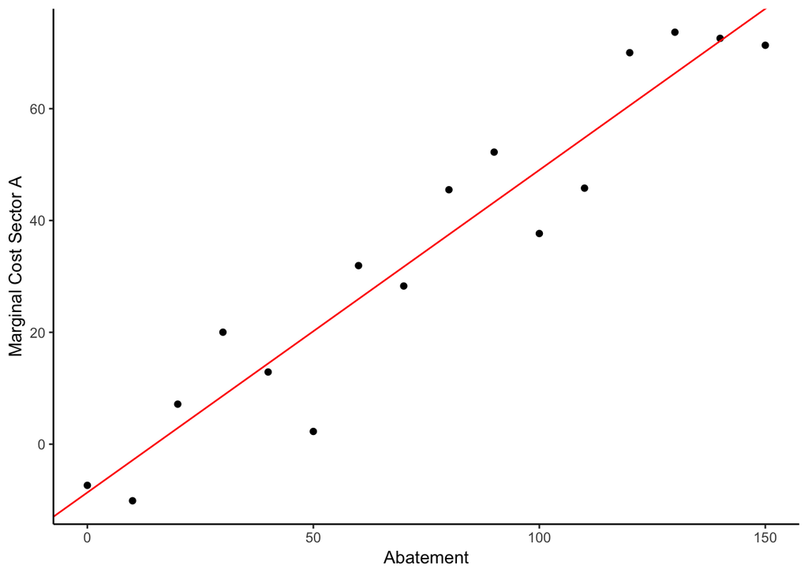

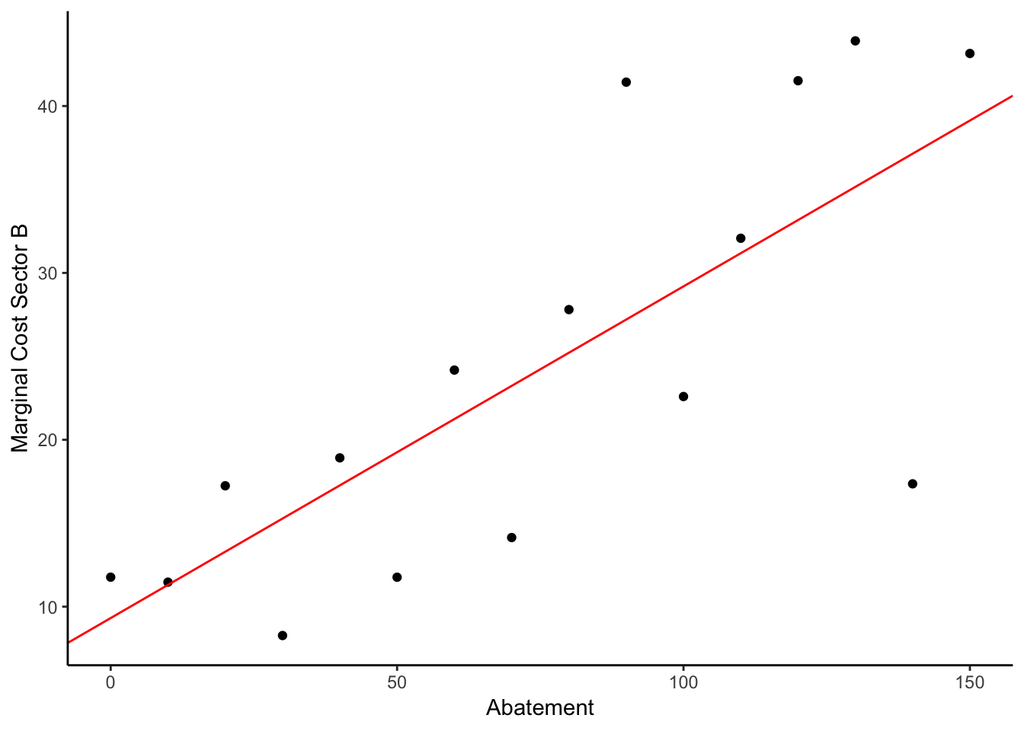

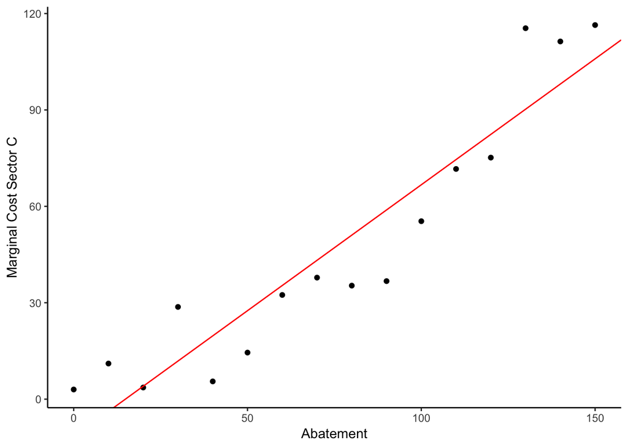

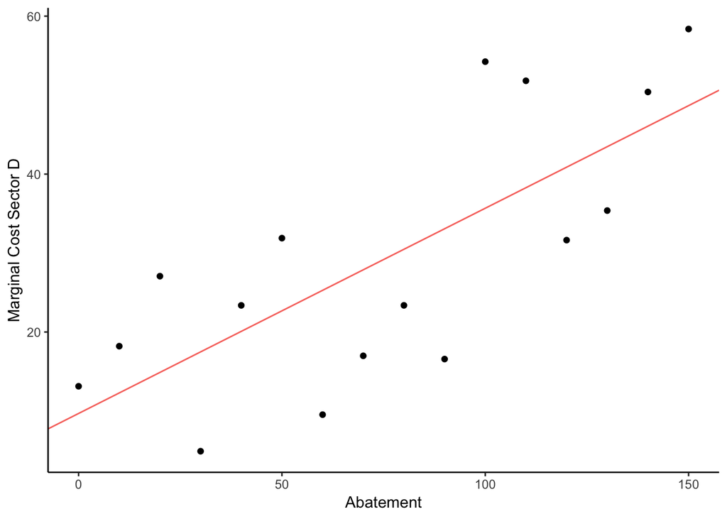

**2. Using these models and the current level of carbon emissions, derive each sector’s demand curve for carbon emissions. In other words, how much would each sector be willing to pay for the right to pollute the first unit, second unit, etc? Draw these demand curves on a graph. Which sector is willing to pay the most for the first unit of carbon emissions?**

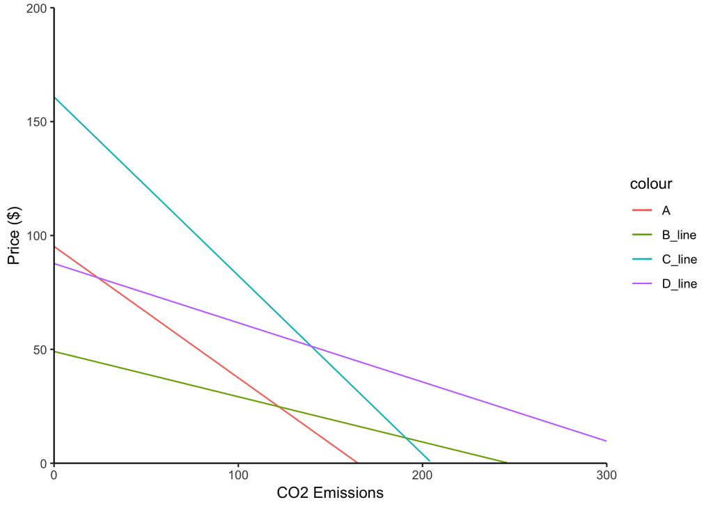

Sector C is willing to pay the most for the first unit of carbon emissions ($160).

**3. Now focus on country X (which contains sectors A, B, and C). Assume there are no “co-benefits” from carbon abatement (i.e. that there are no local pollutants that are affected by carbon abatement). Suppose to meet the Paris Accord commitments, country X needs to cut all carbon emissions in half. For each of the policy options listed below, derive:** - **(1) the total cost of meeting the target in country X** - **(2) the cost (or benefit) to each sector** - **(3) the tax revenue generated.**

**a. Cap on carbon. Each sector (A, B, and C) must cut its carbon emissions by 100 tons (thus reducing total emissions from 600 down to 300).**

- The total cost of meeting the target in country X: $6698.88
- Cost to sector A: $2019.76
- Cost to sector B: $1925.49
- Cost to sector C: $2753.63
- Net Benefit: $1.66339910^{4}

**b. Tax on carbon. To emit a ton of carbon in country X, you must pay a tax of $t. You will need to find the tax that accomplishes the desired reduction.**

- optimal tax: $39.43
- The total cost of meeting the target in country X: $1.77077910^{4}
- Cost to sector A: $5093.79
- Cost to sector B: $5604.63
- Cost to sector C: $7009.37
- tax revenue generated: $11827.97
- Net Benefit: $1.82721310^{4}

**c. Cap and trade. Each sector (A, B, C) is allocated carbon permits equal to their current emissions minus 100 (same as in (a) above), thus achieving the total reduction of 300. Then, these three sectors are allowed to trade with each other. You will need to derive the outcome of that trading.**

- The total cost of meeting the target in country X: $5879.81
- Cost to sector A: $1939.66
- Cost to sector B: $1661.98
- Cost to sector C: $2278.18
- Net Benefit: $1.82721310^{4}

**5. Now assume that every ton of carbon emissions creates 1 ton of local air pollution. Local air pollution causes economic damages (health, environmental, etc.), but only in the country in which it is emitted. Assume there are no local air pollution regulations in either country X or country Y.**

1. In a carbon cap and trade market that only covers sectors in country X, how much local air pollution would you expect in country X? In country Y?
- local air pollution in country x: 300 ton
- Local air pollution in country y: 300 ton
2. If country Y enters the carbon market for country X (as in question 4 above), how much local pollution will there be in country X and country Y?
- local air pollution for counrty x: 377.33 ton
- local air pollution for country y: 222.58 ton
3. What advice can you give country X and country Y about the desirability of allowing international trade of carbon emissions credits?
- If international trade is allowed then you will be able to gain more benefit from the reduction of carbon emissions but this will have a disproportionate effect on local air pollution. Country X will experience more local air pollution than country Y.